# Rmarkdown: Climate change and tuberculosis drive non-adaptive shifts in gut microbiota of wild meerkats

```r
names(year_estimates)<-taxanames

year_estimates_df<-data.frame(do.call(rbind, year_estimates))
```

This chunk took 1.91 minutes

```r
year_estimates_df$Significant <-year_estimates_df$P_val<0.05

year_estimates_df <- year_estimates_df  %>% dplyr::arrange(-effect_size)


year_estimates_unique<-dplyr::distinct(year_estimates_df, Taxa, .keep_all = T)
dim(year_estimates_unique)
```

```
## [1] 31 15
```

```r
taxa_order<-as.character(year_estimates_unique$Taxa)
year_estimates_df$Taxa<-factor(year_estimates_df$Taxa, levels = taxa_order)


########## calculate effect size manually (difference between early and late)

year_estimates_df$Year2<-substr(year_estimates_df$Year, 1, 4)
calculate_effect_size<-subset(year_estimates_df, Year2 <2001 | Year2 > 2014)
calculate_effect_size<-calculate_effect_size[,c(3,9,10, 16)]
calculate_effect_size$Period <- ifelse(calculate_effect_size$Year2 <2001, "EARLY", "LATE")
table(calculate_effect_size$Period)
```

```
##
## EARLY  LATE
##  1147  1147
```

```r
calculate_effect_size<-calculate_effect_size %>% group_by(Taxa, Period) %>% summarize(Mean_est = mean(est_real))

calculate_effect_size_wide<- spread(calculate_effect_size, Period, Mean_est)
head(calculate_effect_size_wide)
```

| Taxa | EARLY | LATE |
| --- | --- | --- |
| Fusobacterium | 1.0315632 | 2.446085 |
| Phascolarctobacterium | 1.2608615 | 2.275884 |
| Bacteroides | 1.1233479 | 2.525285 |
| Parabacteroides | 0.2970058 | 1.426384 |
| Tyzzerella 4 | 0.9675123 | 1.865445 |
| Helicobacter | 0.5335745 | 1.594407 |

```r
calculate_effect_size_wide$Effect<- calculate_effect_size_wide$LATE - calculate_effect_size_wide$EARLY

calculate_effect_size_wide<-merge(calculate_effect_size_wide, year_estimates_df, by = "Taxa")

calculate_effect_size_wide<-distinct(calculate_effect_size_wide, Taxa, .keep_all = T)


calculate_effect_size_wide<-calculate_effect_size_wide %>%arrange(Effect)

taxa_order<-as.character(calculate_effect_size_wide$Taxa)
```

This chunk took 0 minutes

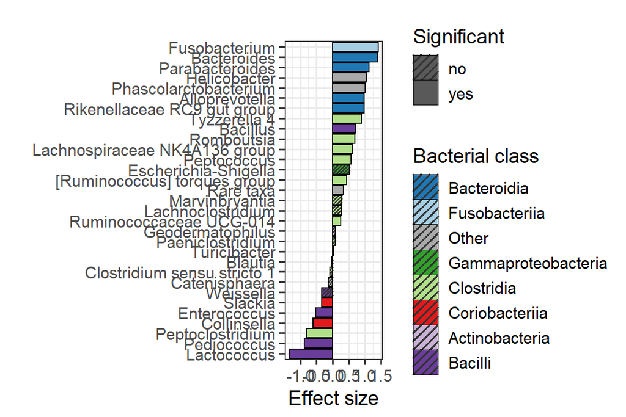

```r
################### plot
################### plot
################### plot

# first add class column so can match colours with earlier figs

taxonomy<-data.frame(tax_table(genus_ps))
tax<-taxonomy[,c("Genus", "Class")]
tax<-distinct(tax, Genus, .keep_all = T)

calculate_effect_size_wide$Class <- vlookup(calculate_effect_size_wide$Taxa, tax, lookup_column = "Genus", result_column = "Class")

calculate_effect_size_wide$Class_plot<-ifelse(calculate_effect_size_wide$Class %in% top_class, calculate_effect_size_wide$Class, "Other")

calculate_effect_size_wide$Class_plot<-factor(calculate_effect_size_wide$Class_plot, levels = c("Bacteroidia","Fusobacteriia" ,  "Other","Gammaproteobacteria", "Clostridia",
                                                                                                "Coriobacteriia","Actinobacteria",    "Bacilli") )

##
calculate_effect_size_wide$Sig <-ifelse(calculate_effect_size_wide$Significant==T, "yes", "no")


plot_tb_1<-ggplot(subset(calculate_effect_size_wide, Taxa != "uncultured"), aes(y = reorder(Taxa, Effect), x = Effect))+
  theme_bw(base_size = 14)+
  geom_bar_pattern(stat = "identity", aes(fill = Class_plot, pattern = Sig),
                   color = "black",
                   pattern_fill = "black",
                   pattern_angle = 45,
                   pattern_density = 0.1,
                   pattern_spacing = 0.025,
                   pattern_key_scale_factor = 0.6)+

  scale_pattern_manual(values = c(no = "stripe", yes = "none"))+
  scale_fill_manual(values = rev(pal))+

  ylab("") +
  theme(plot.margin=unit(c(1,0.2,0.2,0.2),"cm"))+
  xlab("Effect size")+
  labs(pattern = "Significant")+
  labs(fill = "Bacterial class")

plot_tb_1
```

This chunk took 0.06 minutes

### 10.0.2 Models with year as a random effect

- Add variables of interest to models

```r
TB_estimates<-list()
Condition_estimates<-list()
Temp_estimates<-list()
Rainfall_estimates<-list()

taxanames<-unique(top_genera_melt3$Genus2)

for (i in 1:length(taxanames)){
  tryCatch({ #catch errors
    print(i)

    taxa1<-subset(top_genera_melt3, Genus2 == taxanames[i])
    # taxa1<-subset(top_genera_melt3, Genus2 == "Fusobacterium")

    metadata<-taxa1

    #scale variables
    metadata$AgeAtSampling<-as.numeric(scale(log10(metadata$AgeAtSampling)))
    metadata$TotalAbundance<-as.numeric(scale(log10(metadata$TotalAbundance)))
    metadata$Rainfall<-as.numeric(scale(log10(metadata$sum_rainfall_month+1)))
    metadata$Seq_depth_nospikein<-as.numeric(scale(log10(metadata$Seq_depth_nospikein)))


    metadata$TB_stage<-factor(metadata$TB_stage, levels = c("Unexposed", "Exposed","Diseased"))

    metadata$Year<-factor(metadata$Year)

    # fit gamm
    m_taxa <- mgcv::gam(log10(Abundance2+1)~
                          s(HoursAfterSunrise, bs = "cr")+
                          s(month, bs = "cc")+
                          s(AgeAtSampling, bs = "cr")+
                          s(TotalAbundance, bs = "cr")+
                          s(Seq_depth_nospikein, bs = "cr")+
                          TB_stage+
                          Condition_weight+
                          Temp_max+
                          Rainfall+
                          Season+
                          Storage+
                          Seq_run+
                          s(IndividID, bs = "re")+
                          s(Year, bs = "re")+
                          s(GroupAtSampling, bs = "re"),
                        #correlation = corARMA(form = ~ 1|Year, p = 3),
                        data=metadata,
                        family = gaussian)

    summary<-summary(m_taxa)

    ## TB estimates

    TB_estimates_df<-data.frame(summary$p.table)[1:3,]
    TB_estimates_df$Level<-c("Unexposed", "Exposed", "Diseased")
    names(TB_estimates_df)[4]<-"P_val"

    TB_estimates_df$Estimate2<-ifelse(TB_estimates_df$Level == "Unexposed", 0, TB_estimates_df$Estimate)


    TB_estimates_df$lower<-NA
    TB_estimates_df$upper<-NA

    # confidence intervals exposed
    beta <- coef(m_taxa)
    Vb <- vcov(m_taxa, unconditional = TRUE)
    se <- sqrt(diag(Vb))
    j <- which(names(beta) == "(Intercept)")
    cis<- beta[j] + (c(-1,1) * (2 * se[j]))

    TB_estimates_df[1,7]<-cis[1]
    TB_estimates_df[1,8]<-cis[2]

    # confidence intervals exposed
    j <- which(names(beta) == "TB_stageExposed")
    cis<- beta[j] + (c(-1,1) * (2 * se[j]))

    TB_estimates_df[2,7]<-cis[1]
    TB_estimates_df[2,8]<-cis[2]

    # confidence intervals symptomatic
    j <- which(names(beta) == "TB_stageDiseased")
    cis<- beta[j] + (c(-1,1) * (2 * se[j]))

    TB_estimates_df[3,7]<-cis[1]
    TB_estimates_df[3,8]<-cis[2]

    ## add coefficient

    TB_estimates_df$Coef <-as.numeric(coef(m_taxa)[1:3])
    TB_estimates_df$Taxa <-taxanames[i]
    TB_estimates[[i]]<-TB_estimates_df

    ## extract condition stats

    condition_estimates<- data.frame(summary$p.table)[4,]
    condition_estimates$Taxa<-taxanames[i]
    Condition_estimates[[i]]<-condition_estimates

    ## extract max temp stats

    temp_estimates<- data.frame(summary$p.table)[5,]
    temp_estimates$Taxa<-taxanames[i]
    Temp_estimates[[i]]<-temp_estimates

    ## extract rainfall stats

    rainfall_estimates<- data.frame(summary$p.table)[6,]
    rainfall_estimates$Taxa<-taxanames[i]
    Rainfall_estimates[[i]]<-rainfall_estimates


  }, error=function(e){})
}
```

```
## [1] 1
## [1] 2
## [1] 3
## [1] 4
## [1] 5
## [1] 6
## [1] 7
## [1] 8
## [1] 9
## [1] 10
## [1] 11
## [1] 12
## [1] 13
## [1] 14
## [1] 15
```

[output cut: 16 more lines]

This chunk took 14.71 minutes

### 10.0.3 TB estimates

```r
names(TB_estimates)<-taxanames

TB_estimates_df<-do.call(rbind, TB_estimates)


TB_estimates_df$Significant <-TB_estimates_df$P_val < 0.05

# edit significance (intercept will always be significant)

sig_taxa<-subset(TB_estimates_df, Significant == T & Level !="Unexposed")
sig_taxa<-unique(sig_taxa$Taxa)

TB_estimates_df$Significant<- TB_estimates_df$Taxa %in%  sig_taxa


TB_estimates_df
```

|  | Estimate | Std..Error | t.value | P_val | Level | Estimate2 | lower | upper | Coef | Taxa | Significant |
| --- | --- | --- | --- | --- | --- | --- | --- | --- | --- | --- | --- |
| [Ruminococcus] torques group.(Intercept) | 3.238771378 | 0.19045567 | 17.00538197 | 1.134570e-57 | Unexposed | 0.000000000 | 2.857860043 | 3.619682714 | 3.238771378 | [Ruminococcus] torques group | FALSE |
| [Ruminococcus] torques group.TB_stageExposed | 0.111981059 | 0.05809145 | 1.92766857 | 5.415724e-02 | Exposed | 0.111981059 | -0.004201837 | 0.228163955 | 0.111981059 | [Ruminococcus] torques group | FALSE |
| [Ruminococcus] torques group.TB_stageDiseased | 0.031205426 | 0.10234621 | 0.30490064 | 7.605003e-01 | Diseased | 0.031205426 | -0.173487001 | 0.235897853 | 0.031205426 | [Ruminococcus] torques group | FALSE |
| Alloprevotella.(Intercept) | 0.688817505 | 0.23650053 | 2.91254101 | 3.661588e-03 | Unexposed | 0.000000000 | 0.215816436 | 1.161818574 | 0.688817505 | Alloprevotella | FALSE |
| Alloprevotella.TB_stageExposed | 0.103226364 | 0.09014193 | 1.14515367 | 2.524088e-01 | Exposed | 0.103226364 | -0.077057499 | 0.283510227 | 0.103226364 | Alloprevotella | FALSE |
| Alloprevotella.TB_stageDiseased | 0.160280832 | 0.15215875 | 1.05337900 | 2.924118e-01 | Diseased | 0.160280832 | -0.144036667 | 0.464598332 | 0.160280832 | Alloprevotella | FALSE |
| Bacillus.(Intercept) | 0.149277970 | 0.32326070 | 0.46178817 | 6.443269e-01 | Unexposed | 0.000000000 | -0.497243436 | 0.795799375 | 0.149277970 | Bacillus | FALSE |
| Bacillus.TB_stageExposed | 0.106373519 | 0.10780592 | 0.98671311 | 3.240059e-01 | Exposed | 0.106373519 | -0.109238329 | 0.321985367 | 0.106373519 | Bacillus | FALSE |
| Bacillus.TB_stageDiseased | 0.050802295 | 0.17505226 | 0.29021216 | 7.717101e-01 | Diseased | 0.050802295 | -0.299302224 | 0.400906814 | 0.050802295 | Bacillus | FALSE |
| Bacteroides.(Intercept) | 2.311883731 | 0.30179848 | 7.66035590 | 4.071106e-14 | Unexposed | 0.000000000 | 1.708286781 | 2.915480682 | 2.311883731 | Bacteroides | TRUE |

[output cut: 83 more lines]

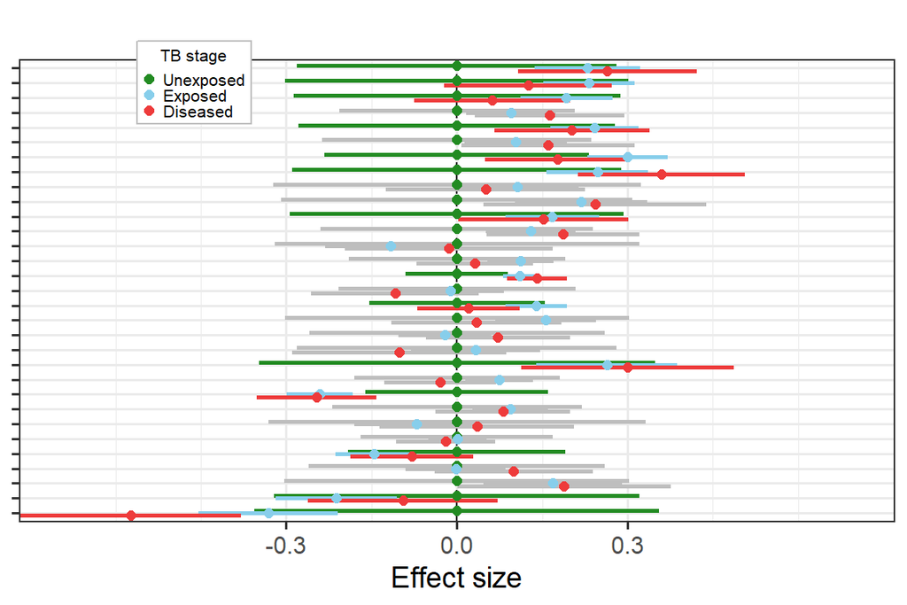

```r
## edit confidence intervals

TB_estimates_df$Level<-factor(TB_estimates_df$Level, levels = c("Diseased", "Exposed", "Unexposed"))

TB_estimates_df$lower<- ifelse(TB_estimates_df$Level == "Unexposed", TB_estimates_df$lower-TB_estimates_df$Estimate, TB_estimates_df$lower)

TB_estimates_df$upper<- ifelse(TB_estimates_df$Level == "Unexposed", TB_estimates_df$upper-TB_estimates_df$Estimate, TB_estimates_df$upper)

# order taxa

TB_estimates_df$Taxa<-factor(TB_estimates_df$Taxa, levels = taxa_order)

#############
#############
#############

plot_tb_2<-ggplot(subset(TB_estimates_df, Taxa!= "uncultured"), aes( x = Estimate2, y = Taxa, group = Level))+
  theme_bw(base_size = 14)+
  geom_vline(xintercept = 0, linetype = "dashed")+
  geom_errorbarh(aes(col = Level, xmin = Estimate2- Std..Error, xmax = Estimate2+ Std..Error), height = 0, size = 1, position=position_dodge(width=0.5))+

  geom_errorbarh(aes(alpha = Significant, xmin = Estimate2- Std..Error, xmax = Estimate2+ Std..Error), height = 0, size = 1, col = "grey", position=position_dodge(width=0.5))+

  scale_alpha_discrete(range = c(1,0), guide = "none")+

  geom_point(aes(col = Level), size = 2, position=position_dodge(width=0.5))+

  scale_color_manual(values = c( "brown2", "skyblue","forestgreen"),  guide = guide_legend(reverse = TRUE))+
  xlim(c(-0.9,NA))+

  theme(axis.text.y = element_blank(), axis.title.y = element_blank())+
  xlab("Effect size")+
  labs(col = "TB stage")+
  theme(plot.margin=unit(c(1,0.2,0.2,0.2),"cm"))+
  # legend
  theme( legend.background = element_blank(),
         legend.box.background = element_rect(colour = "grey", fill = "white"))+
  theme(legend.position=c(0.2,0.95),  legend.direction="vertical",
        legend.key.height = unit(0.05, 'cm'),
        legend.key.width = unit(0.02, 'cm'),
        legend.title=element_text(size=8),
        legend.text =element_text(size=8))+
  guides(colour=guide_legend(title.position="top",                           title.hjust =0.5,reverse = TRUE))+
  coord_cartesian(xlim = c(-0.7, 0.7))  +
  scale_x_continuous(breaks = c(-0.3, 0, 0.3))+
  theme(legend.margin=margin(t = c(0.1,0.1,0.1,0.1), unit='cm'))


plot_tb_2
```

This chunk took 0.01 minutes

### 10.0.4 Body condition estimates

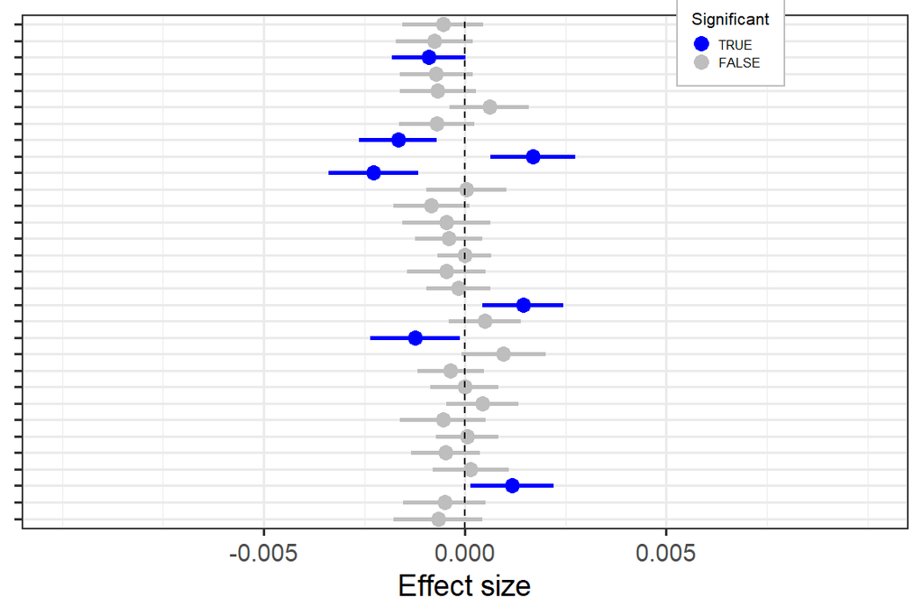

```r
names(Condition_estimates)<-taxanames

condition_estimates_df<-do.call(rbind, Condition_estimates)

condition_estimates_df$Significant <-condition_estimates_df$Pr...t.. < 0.05


condition_estimates_df$Taxa<-factor(condition_estimates_df$Taxa, levels = taxa_order)


plot_condition<-
  ggplot(subset(condition_estimates_df, Taxa!= "uncultured"), aes( x = Estimate, y = Taxa))+
  theme_bw(base_size = 14)+
  geom_point( aes(col = Significant), size = 3)+
  geom_errorbarh(aes(col = Significant, xmin = ((Estimate- Std..Error)-0.0005), xmax = ((Estimate+ Std..Error)+0.0005) ), height = 0, size = 1)+
  geom_vline(xintercept = 0, linetype = "dashed")+
  scale_color_manual(values = c("grey", "blue"))+
  theme(axis.text.y = element_blank(), axis.title.y = element_blank())+
  xlab("Effect size")+
  xlim(c(-0.004,NA))+
  #legend
  theme( legend.background = element_blank(),
         legend.box.background = element_rect(colour = "grey", fill = "white"))+
  theme(legend.position=c(0.8,0.95), legend.direction="vertical",

        legend.key.height = unit(0.02, 'cm'),
        legend.key.width = unit(0.02, 'cm'),
        legend.title=element_text(size=8),
        legend.text =element_text(size=6))+
  guides(colour=guide_legend(title.position="top", reverse = T,
                             title.hjust =0.5))+
  coord_cartesian(xlim = c(-0.01, 0.01))+
  scale_x_continuous(breaks = c(-0.005, 0, 0.005))

plot_condition
```

This chunk took 0 minutes

### 10.0.5 Maximum temp estimates

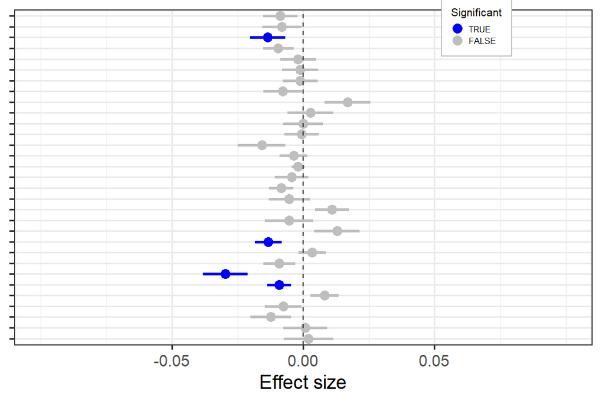

```r
names(Temp_estimates)<-taxanames

temp_estimates_df<-do.call(rbind, Temp_estimates)

temp_estimates_df$Significant <-temp_estimates_df$Pr...t.. < 0.05


temp_estimates_df$Taxa<-factor(temp_estimates_df$Taxa, levels = taxa_order)



plot_temp<-
  ggplot(subset(temp_estimates_df, Taxa!= "uncultured"), aes( x = Estimate, y = Taxa))+
  theme_bw(base_size = 14)+
  geom_point( aes(col = Significant), size = 3)+
  geom_errorbarh(aes(col = Significant, xmin = Estimate- Std..Error, xmax = Estimate+ Std..Error), height = 0, size = 1)+
  geom_vline(xintercept = 0, linetype = "dashed")+
  scale_color_manual(values = c("grey", "blue"))+
  theme(axis.text.y = element_blank(), axis.title.y = element_blank())+
  xlab("Effect size")+
  # xlim(c(-0.004,NA))+
  #legend
  theme( legend.background = element_blank(),
         legend.box.background = element_rect(colour = "grey", fill = "white"))+
  theme(legend.position=c(0.8,0.95), legend.direction="vertical",
        legend.key.height = unit(0.02, 'cm'),
        legend.key.width = unit(0.02, 'cm'),
        legend.title=element_text(size=8),
        legend.text =element_text(size=6))+
  guides(colour=guide_legend(title.position="top", reverse = T,
                             title.hjust =0.5))+
  coord_cartesian(xlim = c(-0.1, 0.1))+
  scale_x_continuous(breaks = c(-0.05, 0, 0.05))

plot_temp
```

This chunk took 0 minutes

### 10.0.6 Rainfall estimates

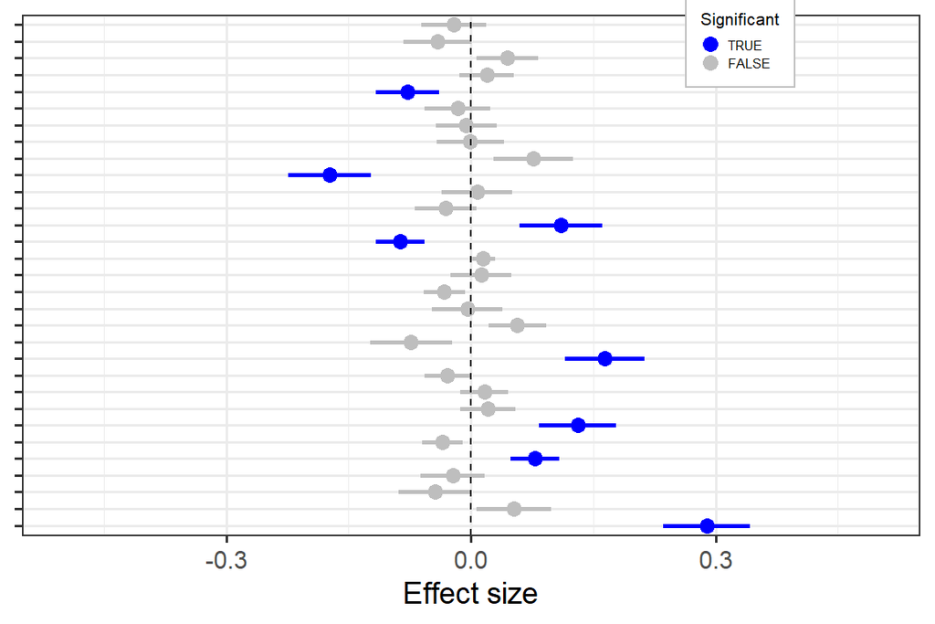

```r
names(Rainfall_estimates)<-taxanames

rainfall_estimates_df<-do.call(rbind, Rainfall_estimates)

rainfall_estimates_df$Significant <-rainfall_estimates_df$Pr...t.. < 0.05

rainfall_estimates_df$Taxa<-factor(rainfall_estimates_df$Taxa, levels = taxa_order)


plot_rainfall<-
  ggplot(subset(rainfall_estimates_df, Taxa!= "uncultured"), aes( x = Estimate, y = Taxa))+
  theme_bw(base_size = 14)+
  geom_point( aes(col = Significant), size = 3)+
  geom_errorbarh(aes(col = Significant, xmin = Estimate- Std..Error, xmax = Estimate+ Std..Error), height = 0, size = 1)+
  geom_vline(xintercept = 0, linetype = "dashed")+
  scale_color_manual(values = c("grey", "blue"))+
  theme(axis.text.y = element_blank(), axis.title.y = element_blank())+
  xlab("Effect size")+
  # xlim(c(-0.004,NA))+
  #legend
  theme( legend.background = element_blank(),
         legend.box.background = element_rect(colour = "grey", fill = "white"))+
  theme(legend.position=c(0.8,0.95), legend.direction="vertical",
        legend.key.height = unit(0.02, 'cm'),
        legend.key.width = unit(0.02, 'cm'),
        legend.title=element_text(size=8),
        legend.text =element_text(size=6))+
  guides(colour=guide_legend(title.position="top", reverse = T,
                             title.hjust =0.5))+
  coord_cartesian(xlim = c(-0.5, 0.5))+
  scale_x_continuous(breaks = c(-0.3, 0, 0.3))

plot_rainfall
```

This chunk took 0 minutes

```r
# Combining plots
rm_legend <- function(p){p + theme(legend.position = "none")}

ggarrange(rm_legend(plot_tb_1), plot_tb_2, plot_rainfall, plot_temp, plot_condition, nrow = 1, align = "h", widths = c(2.2,1,1,1, 1), labels = c("a) Year", "b) TB", "c) Rainfall","d) Max. temp.", "e) Body condition"), label.x = c(0.45,-0.05,-0.15,-0.25, -0.32))
```

[output not shown]

```
## Error in seq.default(from, to, by): invalid '(to - from)/by'
```

```r
#ggsave("Figures/Fig4.pdf")
```

This chunk took 0.01 minutes

# 11 Network analysis

*Need to do CLR analysis from here as this accounts for bacterial load

```r
#### extract site x species array

meerkat_filtered_genus<-tax_glom(meerkat_filtered, taxrank = "Genus")
genus_core<-prune_taxa(top_genera, meerkat_filtered_genus)
taxtable<-data.frame(tax_table(genus_core))
taxa_names(genus_core)<-taxtable$Genus

phylo<-genus_core

taxtable<-data.frame(tax_table(phylo))

taxa_names(phylo)<-taxtable$Genus

phylo_array<-data.frame(t(phylo@otu_table@.Data))


#phylo_array[1:5,1:5]
names(phylo_array)<-taxa_names(phylo)

dim(phylo_array)
```

```
## [1] 1141   30
```

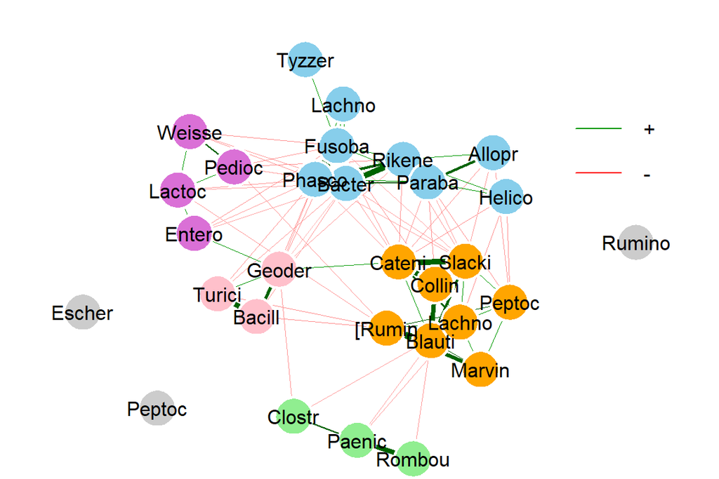

```r
##########################

#### genreate association matrix from the 'real' data
# this uses the package NetCoMi


net_real <- netConstruct(phylo_array, verbose = 0,
                         measure = "spearman",
                         normMethod = "clr",
                         zeroMethod = "none",
                         sparsMethod = "threshold",
                         thresh = 0.3)


props_single <- netAnalyze(net_real,
                           centrLCC = TRUE,
                           clustMethod = "cluster_fast_greedy",
                           hubPar = "eigenvector",
                           weightDeg = FALSE,
                           normDeg = FALSE)



plot(props_single,
     nodeColor = "cluster",
     layout = "spring",
     repulsion = 1,
     # nodeSize = "eigenvector",
     title1 = F,
     #showTitle = TRUE,
     cexTitle = 2.3,
     shortenLabels = "simple",
     labelScale = F,
     nodeSize = "fix",
     colorVec = c("orchid", "skyblue", "orange", "lightgreen", "pink"),
     nodeTransp = 0,
     borderCol = "white",
     borderWidth = 3,
     highlightHubs = F ,
     edgeTranspLow = 0)

legend(0.7, 1.1, cex = 1, title = "Direction",
       legend = c("+","-"), lty = 1, lwd = 1, col = c("#009900","red"),
       bty = "n", horiz = F)
```

```r
cluster_memb<-data.frame(props_single$clustering$clust1)

head(cluster_memb, 20)
```

|  | props_single.clustering.clust1 |
| --- | --- |
| Helicobacter | 2 |
| Geodermatophilus | 5 |
| Fusobacterium | 2 |
| Tyzzerella 4 | 2 |
| [Ruminococcus] torques group | 3 |
| Blautia | 3 |
| Marvinbryantia | 3 |
| Lachnoclostridium | 3 |
| Lachnospiraceae NK4A136 group | 2 |
| Rikenellaceae RC9 gut group | 2 |

[output cut: 10 more lines]

```r
names(cluster_memb)<-"Cluster"

# make singletons their own cluster (not zero)

cluster_memb$Cluster<-ifelse(row.names(cluster_memb)=="Escherichia-Shigella", 6,cluster_memb$Cluster )
cluster_memb$Cluster<-ifelse(row.names(cluster_memb)=="Peptoclostridium", 7,cluster_memb$Cluster )
cluster_memb$Cluster<-ifelse(row.names(cluster_memb)=="Ruminococcaceae UCG-014", 8,cluster_memb$Cluster )


cluster_memb$Cluster2<-case_when(cluster_memb == 1 ~ "Lactococcus cluster",
                                 cluster_memb == 2 ~ "Bacteroides cluster",
                                 cluster_memb == 3 ~ "Blautia cluster",
                                 cluster_memb == 4 ~ "Clostridium cluster",
                                 cluster_memb == 5 ~ "Bacillus cluster",
                                 cluster_memb == 6 ~ "Escherichia-Shigella",
                                 cluster_memb == 7 ~ "Peptoclostridium",
                                 cluster_memb == 8 ~ "Ruminococcus UCG-014" )
```

This chunk took 0.18 minutes

# 12 Survival analysis

```r
meerkat_filtered_genus<-tax_glom(meerkat_filtered, taxrank = "Genus")
genus_core<-prune_taxa(top_genera, meerkat_filtered_genus)
taxtable<-data.frame(tax_table(genus_core))
taxa_names(genus_core)<-taxtable$Genus


### 1) Genus level
### 1) Genus level
### 1) Genus level
### 1) Genus level

survival_df<-data.frame(sample_data(genus_core))
head(survival_df)
```

|  | feature.id | IndividID | SampleDate | SampleTime | Storage | Seq_run | Imtechella | Allobacillus | Seq_depth | scaling_factor | Seq_depth_nospikein | BirthDate | DeathDate | AgeAtSampling | GroupAtSampling | Condition_weight | SocialStatus | Temp_max | sum_rainfall_month | HoursAfterSunrise | TimeCat | Year | month | Season | TB_status | TB_exposure | TB_resistance | TB_survival | TB_symptom_date | … |
| --- | --- | --- | --- | --- | --- | --- | --- | --- | --- | --- | --- | --- | --- | --- | --- | --- | --- | --- | --- | --- | --- | --- | --- | --- | --- | --- | --- | --- | --- | --- |
| Feature1 | Feature1 | ID 69 | 1997-04-18 | 1899-12-30 08:29:00 | FROZEN | RUN1 | 247 | 331 | 27482 | 4.76947866 | 26904 | 1997-03-03 | 2003-12-08 | 46 | Vivian | -101.936750 | Subordinate | 32.7 | 25.4 | 1.545278 | MORNING | 1997 | 4 | WET | Unexposed | NA | NA | NA |  | … |
| Feature3 | Feature3 | ID 69 | 2002-01-06 | 1899-12-30 19:05:00 | FREEZEDRIED | RUN1 | 539 | 562 | 41374 | 2.80907017 | 40273 | 1997-03-03 | 2003-12-08 | 1770 | Rascals | -52.337928 | Subordinate | 37.7 | 13.2 | 13.231944 | AFTERNOON | 2002 | 1 | WET | Unexposed | NA | NA | NA |  | … |
| Feature5 | Feature5 | ID 4 | 2002-04-28 | 1899-12-30 09:50:00 | FREEZEDRIED | RUN1 | 252 | 301 | 31022 | 5.24484198 | 30469 | 1998-10-21 | 2003-06-25 | 1285 | Vivian | 6.768133 | Dominant | 34.3 | 19.2 | 2.810000 | MORNING | 2002 | 4 | WET | Unexposed | NA | NA | NA |  | … |
| Feature7 | Feature7 | ID 92 | 2002-05-18 | 1899-12-30 12:25:00 | FREEZEDRIED | RUN4 | 24166 | 25045 | 80435 | 0.06303444 | 31224 | 2000-03-16 | 2007-01-26 | 793 | Whiskers | -4.147200 | Dominant | 29.0 | 18.4 | 5.207222 | MORNING | 2002 | 5 | DRY | Unexposed | NA | NA | NA |  | … |
| Feature8 | Feature8 | ID 1 | 2002-08-20 | 1899-12-30 09:20:00 | FROZEN | RUN1 | 649 | 855 | 33373 | 1.84642975 | 31869 | 1996-01-03 | 2004-02-23 | 2421 | Frisky | -61.905933 | Subordinate | 23.1 | 0.2 | 2.243056 | MORNING | 2002 | 8 | DRY | Unexposed | NA | NA | NA |  | … |
| Feature10 | Feature10 | ID 35 | 2002-08-25 | 1899-12-30 10:48:00 | FREEZEDRIED | RUN1 | 130 | 137 | 31232 | 11.52333895 | 30965 | 1999-01-20 | 2004-11-15 | 1313 | Zappa | -16.699624 | Subordinate | 26.6 | 0.2 | 3.789167 | MORNING | 2002 | 8 | DRY | Diseased | 595 | 20 | 615 | 2004-10-26 | … |

```r
# calculate if ID is alive 6 months later, TRUE = dead

survival_df$Time_180<-survival_df$SampleDate+180
survival_df$Survival_180<- ifelse(survival_df$Time_180 < survival_df$DeathDate, FALSE,TRUE)


table(survival_df$Survival_180)
```

```
##
## FALSE  TRUE
##   811   330
```

```r
survival_df$FollowUp_180<-180


## add on genus level abundance
genus_clr<-microbiome::transform(genus_core, transform = "clr")

otutable<-data.frame(t(otu_table(genus_clr)))
otutable[1:5, 1:5]
```

|  | Helicobacter | Geodermatophilus | Fusobacterium | Tyzzerella.4 | X.Ruminococcus..torques.group |
| --- | --- | --- | --- | --- | --- |
| Feature1 | -2.693577 | 3.7402084 | -2.693577333 | 1.7668794 | 3.478613 |
| Feature3 | -4.422940 | 1.5185686 | 0.006143551 | 0.2171553 | 3.775428 |
| Feature5 | -3.905599 | 0.7932801 | -3.905598581 | -3.9055986 | 1.496985 |
| Feature7 | -4.210531 | 5.2401225 | -4.210531377 | 0.3675694 | 3.535728 |
| Feature8 | -4.571879 | 2.2989251 | 2.163005820 | -0.2536494 | 3.753022 |

```r
names(otutable)<-taxa_names(genus_clr)
names(otutable)<-make.names(names(otutable),unique = TRUE)
otutable<-data.frame(scale(otutable))
#hist(otutable$Helicobacter)

survival_df_genus<-merge(survival_df, otutable, by = 0)
head(survival_df_genus)
```

|  | Row.names | feature.id | IndividID | SampleDate | SampleTime | Storage | Seq_run | Imtechella | Allobacillus | Seq_depth | scaling_factor | Seq_depth_nospikein | BirthDate | DeathDate | AgeAtSampling | GroupAtSampling | Condition_weight | SocialStatus | Temp_max | sum_rainfall_month | HoursAfterSunrise | TimeCat | Year | month | Season | TB_status | TB_exposure | TB_resistance | TB_survival | … |
| --- | --- | --- | --- | --- | --- | --- | --- | --- | --- | --- | --- | --- | --- | --- | --- | --- | --- | --- | --- | --- | --- | --- | --- | --- | --- | --- | --- | --- | --- | --- |
| 1 | Feature1 | Feature1 | ID 69 | 1997-04-18 | 1899-12-30 08:29:00 | FROZEN | RUN1 | 247 | 331 | 27482 | 4.769479 | 26904 | 1997-03-03 | 2003-12-08 | 46 | Vivian | -101.936750 | Subordinate | 32.7 | 25.4 | 1.5452778 | MORNING | 1997 | 4 | WET | Unexposed | NA | NA | NA | … |
| 2 | Feature10 | Feature10 | ID 35 | 2002-08-25 | 1899-12-30 10:48:00 | FREEZEDRIED | RUN1 | 130 | 137 | 31232 | 11.523339 | 30965 | 1999-01-20 | 2004-11-15 | 1313 | Zappa | -16.699624 | Subordinate | 26.6 | 0.2 | 3.7891667 | MORNING | 2002 | 8 | DRY | Diseased | 595 | 20 | 615 | … |
| 3 | Feature100 | Feature100 | ID 8 | 2004-09-28 | 1899-12-30 09:42:00 | FROZEN | RUN1 | 172 | 210 | 23208 | 7.517607 | 22826 | 2000-10-09 | 2007-03-05 | 1450 | Young Ones | -6.095582 | Subordinate | 25.5 | 7.2 | 3.3275000 | MORNING | 2004 | 9 | DRY | Exposed | NA | NA | 124 | … |
| 4 | Feature1000 | Feature1000 | ID 142 | 2016-12-28 | 1899-12-30 08:40:00 | FREEZEDRIED | RUN1 | 118 | 237 | 34551 | 6.661171 | 34196 | 2012-09-27 | 2017-02-02 | 1553 | Ewoks | -93.151640 | Subordinate | 36.1 | 17.0 | 2.9127778 | MORNING | 2016 | 12 | WET | Diseased | 249 | 71 | 320 | … |
| 5 | Feature1001 | Feature1001 | ID 198 | 2016-12-29 | 1899-12-30 08:41:00 | FREEZEDRIED | RUN3 | 50 | 121 | 19003 | 13.047086 | 18832 | 2015-01-20 | 2018-01-20 | 709 | Baobab | 25.985040 | Dominant | 35.9 | 19.4 | 2.9194444 | MORNING | 2016 | 12 | WET | Diseased | 517 | 580 | 1097 | … |
| 6 | Feature1002 | Feature1002 | ID 225 | 2016-12-31 | 1899-12-30 06:44:00 | FREEZEDRIED | RUN2 | 78 | 193 | 32887 | 8.179779 | 32616 | 2016-11-19 | 2018-07-06 | 42 | Baobab | -148.779682 | Subordinate | 39.6 | 19.4 | 0.9486111 | MORNING | 2016 | 12 | WET | Diseased | 320 | 275 | 595 | … |

```r
# model

names(survival_df_genus)
```

```
##  [1] "Row.names"                     "feature.id"
##  [3] "IndividID"                     "SampleDate"
##  [5] "SampleTime"                    "Storage"
##  [7] "Seq_run"                       "Imtechella"
##  [9] "Allobacillus"                  "Seq_depth"
## [11] "scaling_factor"                "Seq_depth_nospikein"
## [13] "BirthDate"                     "DeathDate"
## [15] "AgeAtSampling"                 "GroupAtSampling"
## [17] "Condition_weight"              "SocialStatus"
## [19] "Temp_max"                      "sum_rainfall_month"
## [21] "HoursAfterSunrise"             "TimeCat"
## [23] "Year"                          "month"
## [25] "Season"                        "TB_status"
## [27] "TB_exposure"                   "TB_resistance"
## [29] "TB_survival"                   "TB_symptom_date"
```

[output cut: 18 more lines]

```r
#survival_df_genus<-survival_df_genus[,c(2, 30, 31,8, 13,20,27,19,18,32:60)]
names(survival_df_genus)
```

```
##  [1] "Row.names"                     "feature.id"
##  [3] "IndividID"                     "SampleDate"
##  [5] "SampleTime"                    "Storage"
##  [7] "Seq_run"                       "Imtechella"
##  [9] "Allobacillus"                  "Seq_depth"
## [11] "scaling_factor"                "Seq_depth_nospikein"
## [13] "BirthDate"                     "DeathDate"
## [15] "AgeAtSampling"                 "GroupAtSampling"
## [17] "Condition_weight"              "SocialStatus"
## [19] "Temp_max"                      "sum_rainfall_month"
## [21] "HoursAfterSunrise"             "TimeCat"
## [23] "Year"                          "month"
## [25] "Season"                        "TB_status"
## [27] "TB_exposure"                   "TB_resistance"
## [29] "TB_survival"                   "TB_symptom_date"
```

[output cut: 18 more lines]

```r
survival_df_genus$AgeAtSampling<-scale(log10(survival_df_genus$AgeAtSampling))
survival_df_genus$Condition_weight<-scale(survival_df_genus$Condition_weight)
survival_df_genus$IndividID<-as.character(survival_df_genus$IndividID)
survival_df_genus$Season <-case_when(survival_df_genus$Season == "WET" ~ "Wet",
                                     survival_df_genus$Season == "DRY" ~ "Dry")
names(survival_df_genus)[15]<-"Age"

survival_df_genus<-subset(survival_df_genus, !is.na(Survival_180))
dim(survival_df_genus)
```

```
## [1] 1141   66
```

```r
#survival_df_genus$Survival<-Surv(survival_df_genus$FollowUp_180, survival_df_genus$Survival_180)


frmla <- as.formula(paste("Surv(FollowUp_180, Survival_180)",
                          paste(names(survival_df_genus)[5:38],  sep = "",
                                collapse = " + "), sep = " ~ "))

frmla <-update.formula(frmla, ~ . + (1|IndividID))



fit_genus <- coxme::coxme(Surv(FollowUp_180, Survival_180) ~
                            Age +
                            Season +
                            TB_stage +
                            SocialStatus +
                            Condition_weight +
                            Fusobacterium+
                            Bacteroides+
                            Parabacteroides+
                            Phascolarctobacterium+
                            Helicobacter +
                            Alloprevotella+
                            Enterococcus +
                            Pediococcus +
                            Lactococcus+
                            Peptoclostridium+
                            Collinsella+
                            Slackia+

                            (1 | IndividID),
                          data = survival_df_genus)


fit_genus
```

```
## Cox mixed-effects model fit by maximum likelihood
##   Data: survival_df_genus
##   events, n = 330, 1141
##   Iterations= 24 150
##                     NULL Integrated    Fitted
## Log-likelihood -2270.128  -2065.913 -1911.819
##
##                    Chisq     df p    AIC    BIC
## Integrated loglik 408.43  19.00 0 370.43 298.25
##  Penalized loglik 716.62 133.39 0 449.84 -56.92
##
## Model:  Surv(FollowUp_180, Survival_180) ~ Age + Season + TB_stage +      SocialStatus + Condition_weight + Fusobacterium + Bacteroides +      Parabacteroides + Phascolarctobacterium + Helicobacter +      Alloprevotella + Enterococcus + Pediococcus + Lactococcus +      Peptoclostridium + Collinse…
## Fixed coefficients
##                                 coef exp(coef)   se(coef)     z       p
## Age                      1.578270076 4.8465644 0.12349691 12.78 0.0e+00
## SeasonWet               -0.345947098 0.7075499 0.13207267 -2.62 8.8e-03
## TB_stageExposed          1.468404417 4.3423011 0.21576219  6.81 1.0e-11
## TB_stageDiseased         2.253788964 9.5237527 0.26572017  8.48 0.0e+00
## SocialStatusSubordinate  0.716211386 2.0466645 0.21278473  3.37 7.6e-04
## Condition_weight        -0.280096365 0.7557109 0.06493959 -4.31 1.6e-05
## Fusobacterium            0.079388592 1.0826249 0.08837575  0.90 3.7e-01
## Bacteroides             -0.089877390 0.9140432 0.10342463 -0.87 3.8e-01
## Parabacteroides          0.019271270 1.0194582 0.09393135  0.21 8.4e-01
## Phascolarctobacterium   -0.128020564 0.8798353 0.09877150 -1.30 1.9e-01
## Helicobacter            -0.052896360 0.9484783 0.07958094 -0.66 5.1e-01
## Alloprevotella           0.082769014 1.0862909 0.07785428  1.06 2.9e-01
## Enterococcus            -0.090187680 0.9137597 0.07411484 -1.22 2.2e-01
## Pediococcus             -0.102416622 0.9026534 0.07462879 -1.37 1.7e-01
## Lactococcus             -0.092793469 0.9113817 0.07505914 -1.24 2.2e-01
## Peptoclostridium        -0.007256337 0.9927699 0.07105360 -0.10 9.2e-01
## Collinsella              0.112057996 1.1185777 0.08414084  1.33 1.8e-01
## Slackia                 -0.092482014 0.9116656 0.08569759 -1.08 2.8e-01
##
## Random effects
##  Group     Variable  Std Dev  Variance
##  IndividID Intercept 1.045863 1.093830
```

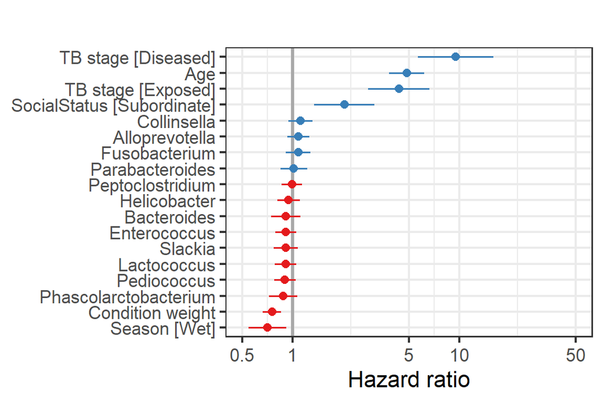

```r
sjPlot::plot_model(fit_genus, axis.lim = c(0.8,20), vline.color = "darkgrey", sort.est = T)+  theme_bw(base_size = 16)+ggtitle("")+ylab("Hazard ratio")
```

```r
#options(na.action = "na.fail")

#dredge_genus_df<- MuMIn::dredge(fit_genus, fixed = c("Age", "Season", "TB_stage",
# "SocialStatus", "Condition_weight"))

#write.csv(dredge_genus_df, "dredge_results_genus.csv")


######### 2) Network approach ############
######### 2) Network approach ############
######### 2) Network approach ############
######### 2) Network approach ############


pseq_network<-genus_core
head(cluster_memb)
```

|  | Cluster | Cluster2 |
| --- | --- | --- |
| Helicobacter | 2 | Bacteroides cluster |
| Geodermatophilus | 5 | Bacillus cluster |
| Fusobacterium | 2 | Bacteroides cluster |
| Tyzzerella 4 | 2 | Bacteroides cluster |
| [Ruminococcus] torques group | 3 | Blautia cluster |
| Blautia | 3 | Blautia cluster |

```r
tail(cluster_memb)
```

|  | Cluster | Cluster2 |
| --- | --- | --- |
| Clostridium sensu stricto 1 | 4 | Clostridium cluster |
| Peptococcus | 3 | Blautia cluster |
| Phascolarctobacterium | 2 | Bacteroides cluster |
| Ruminococcaceae UCG-014 | 8 | Ruminococcus UCG-014 |
| Slackia | 3 | Blautia cluster |
| Escherichia-Shigella | 6 | Escherichia-Shigella |

```r
pseq_network@tax_table@.Data[,1]<-cluster_memb$Cluster2

pseq_network@tax_table@.Data
```

```
##                               Kingdom                Phylum
## Helicobacter                  "Bacteroides cluster"  "Epsilonbacteraeota"
## Geodermatophilus              "Bacillus cluster"     "Actinobacteria"
## Fusobacterium                 "Bacteroides cluster"  "Fusobacteria"
## Tyzzerella 4                  "Bacteroides cluster"  "Firmicutes"
## [Ruminococcus] torques group  "Blautia cluster"      "Firmicutes"
## Blautia                       "Blautia cluster"      "Firmicutes"
## Marvinbryantia                "Blautia cluster"      "Firmicutes"
## Lachnoclostridium             "Blautia cluster"      "Firmicutes"
## Lachnospiraceae NK4A136 group "Bacteroides cluster"  "Firmicutes"
## Rikenellaceae RC9 gut group   "Bacteroides cluster"  "Bacteroidetes"
## Bacteroides                   "Bacteroides cluster"  "Bacteroidetes"
## Alloprevotella                "Bacteroides cluster"  "Bacteroidetes"
## Parabacteroides               "Bacteroides cluster"  "Bacteroidetes"
## Paeniclostridium              "Clostridium cluster"  "Firmicutes"
## Romboutsia                    "Clostridium cluster"  "Firmicutes"
## Peptoclostridium              "Peptoclostridium"     "Firmicutes"
## Collinsella                   "Blautia cluster"      "Actinobacteria"
## Enterococcus                  "Lactococcus cluster"  "Firmicutes"
## Pediococcus                   "Lactococcus cluster"  "Firmicutes"
## Weissella                     "Lactococcus cluster"  "Firmicutes"
## Bacillus                      "Bacillus cluster"     "Firmicutes"
## Turicibacter                  "Bacillus cluster"     "Firmicutes"
## Catenisphaera                 "Blautia cluster"      "Firmicutes"
## Lactococcus                   "Lactococcus cluster"  "Firmicutes"
## Clostridium sensu stricto 1   "Clostridium cluster"  "Firmicutes"
## Peptococcus                   "Blautia cluster"      "Firmicutes"
## Phascolarctobacterium         "Bacteroides cluster"  "Firmicutes"
## Ruminococcaceae UCG-014       "Ruminococcus UCG-014" "Firmicutes"
## Slackia                       "Blautia cluster"      "Actinobacteria"
## Escherichia-Shigella          "Escherichia-Shigella" "Proteobacteria"
##                               Class                 Order
## Helicobacter                  "Campylobacteria"     "Campylobacterales"
## Geodermatophilus              "Actinobacteria"      "Frankiales"
## Fusobacterium                 "Fusobacteriia"       "Fusobacteriales"
## Tyzzerella 4                  "Clostridia"          "Clostridiales"
## [Ruminococcus] torques group  "Clostridia"          "Clostridiales"
## Blautia                       "Clostridia"          "Clostridiales"
## Marvinbryantia                "Clostridia"          "Clostridiales"
## Lachnoclostridium             "Clostridia"          "Clostridiales"
```

[output cut: 69 more lines]

```
## Peptoclostridium              "Peptoclostridium"              NA
## Collinsella                   "Collinsella"                   NA
## Enterococcus                  "Enterococcus"                  NA
## Pediococcus                   "Pediococcus"                   NA
## Weissella                     "Weissella"                     NA
## Bacillus                      "Bacillus"                      NA
## Turicibacter                  "Turicibacter"                  NA
## Catenisphaera                 "Catenisphaera"                 NA
## Lactococcus                   "Lactococcus"                   NA
## Clostridium sensu stricto 1   "Clostridium sensu stricto 1"   NA
## Peptococcus                   "Peptococcus"                   NA
## Phascolarctobacterium         "Phascolarctobacterium"         NA
## Ruminococcaceae UCG-014       "Ruminococcaceae UCG-014"       NA
## Slackia                       "Slackia"                       NA
## Escherichia-Shigella          "Escherichia-Shigella"          NA
```

```r
pseq_network2<-tax_glom(pseq_network, taxrank = "Kingdom")
pseq_network2<-microbiome::transform(pseq_network2, "clr")
taxa_names(pseq_network2)
```

```
## [1] "Blautia"                     "Bacteroides"
## [3] "Peptoclostridium"            "Enterococcus"
## [5] "Bacillus"                    "Clostridium sensu stricto 1"
## [7] "Ruminococcaceae UCG-014"     "Escherichia-Shigella"
```

```r
taxa_names(pseq_network2)<-c("Blautia_cluster", "Bacteroides_cluster", "Peptoclostridium", "Lactococcus_cluster", "Bacillus_cluster", "Clostridium_cluster", "Ruminococcus_UCG-014", "Escherichia-Shigella")


otutable<-data.frame(t(otu_table(pseq_network2)))
otutable[1:5, 1:5]
```

|  | Blautia_cluster | Bacteroides_cluster | Peptoclostridium | Lactococcus_cluster | Bacillus_cluster |
| --- | --- | --- | --- | --- | --- |
| Feature1 | 3.751603 | -1.508406 | 1.988898 | 0.08678291 | 0.4606976 |
| Feature3 | 3.400688 | -1.215998 | -1.168177 | 0.84235863 | -0.8010328 |
| Feature5 | 2.700791 | -1.066949 | -5.235182 | 2.40636580 | 0.8777473 |
| Feature7 | 4.417280 | -0.714125 | -5.627641 | 2.36988011 | 3.6730418 |
| Feature8 | 4.839720 | 2.035009 | -5.539883 | 2.56028651 | 0.9765845 |

```r
otutable<-data.frame(scale(otutable))
#hist(otutable$Helicobacter)

survival_df_network<-merge(survival_df, otutable, by = 0)



#############
#############
#############
#############

names(survival_df_network)
```

```
##  [1] "Row.names"            "feature.id"           "IndividID"
##  [4] "SampleDate"           "SampleTime"           "Storage"
##  [7] "Seq_run"              "Imtechella"           "Allobacillus"
## [10] "Seq_depth"            "scaling_factor"       "Seq_depth_nospikein"
## [13] "BirthDate"            "DeathDate"            "AgeAtSampling"
## [16] "GroupAtSampling"      "Condition_weight"     "SocialStatus"
## [19] "Temp_max"             "sum_rainfall_month"   "HoursAfterSunrise"
## [22] "TimeCat"              "Year"                 "month"
## [25] "Season"               "TB_status"            "TB_exposure"
## [28] "TB_resistance"        "TB_survival"          "TB_symptom_date"
## [31] "TB_exposure_date"     "TB_stage"             "TotalAbundance"
## [34] "Time_180"             "Survival_180"         "FollowUp_180"
## [37] "Blautia_cluster"      "Bacteroides_cluster"  "Peptoclostridium"
## [40] "Lactococcus_cluster"  "Bacillus_cluster"     "Clostridium_cluster"
## [43] "Ruminococcus_UCG.014" "Escherichia.Shigella"
```

```r
#survival_df_network<-survival_df_network[,c(2, 8,30, 31, 13,20,27,19,18,32:38)]
#names(survival_df_network)
survival_df_network$AgeAtSampling<-scale(log10(survival_df_network$AgeAtSampling))
survival_df_network$Condition_weight<-scale(survival_df_network$Condition_weight)
survival_df_network$IndividID<-as.character(survival_df_network$IndividID)

survival_df_network$Season <-case_when(survival_df_network$Season == "WET" ~ "Wet",
                                       survival_df_network$Season == "DRY" ~ "Dry")
names(survival_df_network)[15]<-"Age"

survival_df_network<-subset(survival_df_network, !is.na(Survival_180))
dim(survival_df_network)
```

```
## [1] 1141   44
```

```r
#survival_df_network$Survival<-Surv(survival_df_network$FollowUp_180, survival_df_network$Survival_180)


frmla <- as.formula(paste("Surv(FollowUp_180, Survival_180)",
                          paste(names(survival_df_network)[5:16],  sep = "",
                                collapse = " + "), sep = " ~ "))

frmla <-update.formula(frmla, ~ . + (1|IndividID))


fit_network <- coxme::coxme(Surv(FollowUp_180, Survival_180) ~ Age +
                              Season +
                              TB_stage +
                              SocialStatus +
                              Condition_weight +
                              Blautia_cluster +
                              Bacteroides_cluster +
                              Peptoclostridium +
                              Lactococcus_cluster +
                              Bacillus_cluster +
                              Clostridium_cluster +
                              Ruminococcus_UCG.014  +
                              (1 | IndividID),
                            data = survival_df_network)

summary(fit_network)
```

```
## Cox mixed-effects model fit by maximum likelihood
##   Data: survival_df_network
##   events, n = 330, 1141
##   Iterations= 23 144
##                     NULL Integrated    Fitted
## Log-likelihood -2270.128  -2068.655 -1911.604
##
##                    Chisq    df p    AIC    BIC
## Integrated loglik 402.95  14.0 0 374.95 321.76
##  Penalized loglik 717.05 130.5 0 456.04 -39.75
##
## Model:  Surv(FollowUp_180, Survival_180) ~ Age + Season + TB_stage +      SocialStatus + Condition_weight + Blautia_cluster + Bacteroides_cluster +      Peptoclostridium + Lactococcus_cluster + Bacillus_cluster +      Clostridium_cluster + Ruminococcus_UCG.014 + (1 | IndividID)
## Fixed coefficients
##                                coef exp(coef)   se(coef)     z       p
## Age                      1.58457919 4.8772386 0.12297031 12.89 0.0e+00
## SeasonWet               -0.37548490 0.6869561 0.13091206 -2.87 4.1e-03
## TB_stageExposed          1.48157845 4.3998852 0.21751584  6.81 9.7e-12
## TB_stageDiseased         2.30012696 9.9754488 0.26435469  8.70 0.0e+00
## SocialStatusSubordinate  0.73367572 2.0827221 0.21348281  3.44 5.9e-04
## Condition_weight        -0.27935861 0.7562687 0.06611843 -4.23 2.4e-05
## Blautia_cluster          0.00471949 1.0047306 0.06993167  0.07 9.5e-01
## Bacteroides_cluster     -0.02101547 0.9792038 0.09795373 -0.21 8.3e-01
## Peptoclostridium        -0.04365207 0.9572870 0.08516750 -0.51 6.1e-01
## Lactococcus_cluster     -0.16382231 0.8488928 0.08240857 -1.99 4.7e-02
## Bacillus_cluster         0.03871740 1.0394767 0.08558698  0.45 6.5e-01
## Clostridium_cluster     -0.09186031 0.9122326 0.08657432 -1.06 2.9e-01
## Ruminococcus_UCG.014    -0.05779993 0.9438388 0.07910965 -0.73 4.7e-01
##
## Random effects
##  Group     Variable  Std Dev  Variance
##  IndividID Intercept 1.064405 1.132957
```

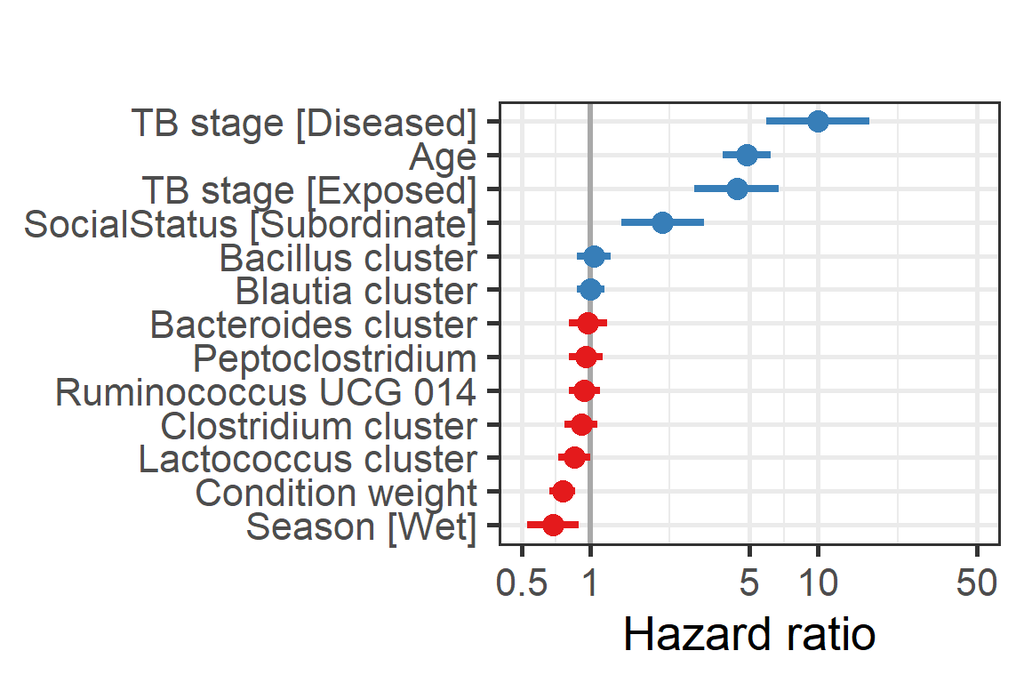

```r
sjPlot::plot_model(fit_network, axis.lim = c(0.8,11),
                   vline.color = "darkgrey", sort.est = T,
                   dot.size= 4, line.size = 1.5, show.p = T)+
  theme_bw(base_size = 20)+ggtitle("")+ylab("Hazard ratio")
```

This chunk took 0.14 minutes

# 13 Longitudinal analysis

```r
table(sample_data(meerkat_filtered)$TB_status)
```

```
##
## Unexposed   Exposed  Diseased
##       140       524       477
```

```r
table(sample_data(meerkat_filtered)$TB_stage)
```

```
##
## Unexposed   Exposed  Diseased
##       421       630        90
```

```r
ps_infected<-subset_samples(meerkat_filtered, TB_status !="Unexposed")

tb_df<-data.frame(table(sample_data(ps_infected)$IndividID, sample_data(ps_infected)$TB_stage))
tb_df2<-subset(tb_df, Var2 == "Diseased")
tb_df3<- subset(tb_df2, Freq>0)
id_keep<-as.character(tb_df3$Var1)

sample_data(ps_infected)$Keep<-sample_data(ps_infected)$IndividID %in% id_keep

ps_infected2<- subset_samples(ps_infected, Keep == T)

tb_df<-data.frame(table(sample_data(ps_infected)$IndividID, sample_data(ps_infected)$TB_stage))
tb_df2<-subset(tb_df, Var2 == "Unexposed")
tb_df3<- subset(tb_df2, Freq>0)
id_keep<-as.character(tb_df3$Var1)


sample_data(ps_infected2)$Keep<-sample_data(ps_infected2)$IndividID %in% id_keep

ps_infected3<- subset_samples(ps_infected2, Keep == T)

length(unique(sample_data(ps_infected3)$IndividID))
```

```
## [1] 11
```

```r
table(sample_data(ps_infected3)$TB_stage)
```

```
##
## Unexposed   Exposed  Diseased
##        50        15        21
```

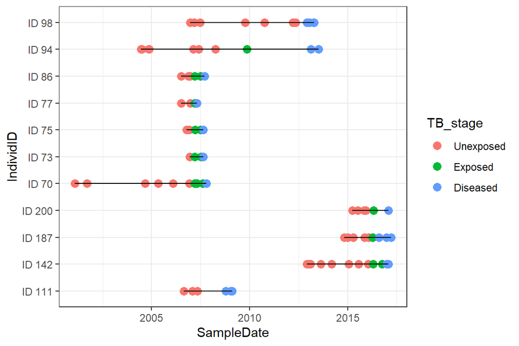

```r
ggplot(sample_data(ps_infected3), aes(x = SampleDate, y = IndividID, group = IndividID))+geom_point(aes(col = TB_stage), size = 3)+geom_line()+ theme_bw()
```

This chunk took 0.05 minutes

- Plot around exposure date

```r
sample_data(ps_infected3)$Days_exposure<- sample_data(ps_infected3)$SampleDate - sample_data(ps_infected3)$TB_exposure_date
sample_data(ps_infected3)$BeforeExposure <- sample_data(ps_infected3)$SampleDate < sample_data(ps_infected3)$TB_exposure_date
table(sample_data(ps_infected3)$BeforeExposure)
```

```
##
## FALSE  TRUE
##    36    50
```

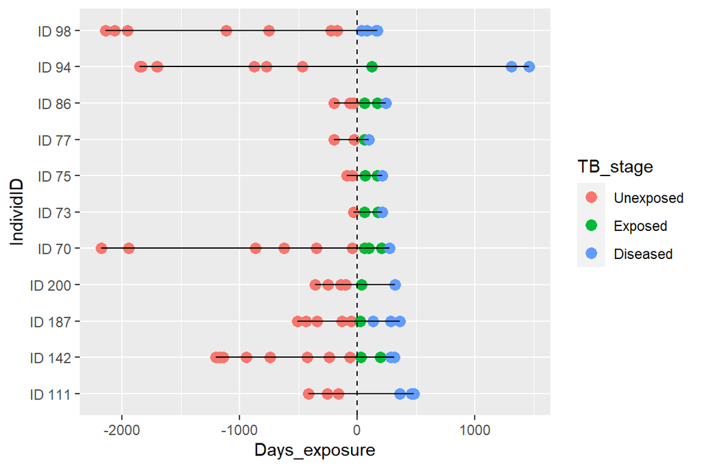

```r
ggplot(sample_data(ps_infected3), aes(x = Days_exposure, y = IndividID, group = IndividID))+geom_point(aes(col = TB_stage), size = 3)+geom_line()+geom_vline(xintercept = 0, linetype = "dashed")
```

This chunk took 0.01 minutes

### 13.0.1 Repeat GAM models

```r
genus_ps<-tax_glom(ps_infected3, taxrank = "Genus")
#genus_ps<-tax_glom(subset_samples(ps_infected3, Storage == "FREEZEDRIED"), taxrank = "Genus")

genus_abundances_df<-data.frame(taxa_sums(genus_ps))

genus_abundances_df$ASV<-row.names(genus_abundances_df)

taxonomy<-data.frame(tax_table(genus_ps))
taxonomy$ASV<-row.names(taxonomy)
sample_data(genus_ps)<-sample_data(genus_ps)[,c( "feature.id")]

top_genera_melt<-psmelt(genus_ps)


# make a category for rare genera

top_genera_melt$Genus2<-ifelse(top_genera_melt$OTU %in% top_genera, top_genera_melt$Genus, "Rare taxa")

head(top_genera_melt)
```

|  | OTU | Sample | Abundance | feature.id | Kingdom | Phylum | Class | Order | Family | Genus | Species | Genus2 |
| --- | --- | --- | --- | --- | --- | --- | --- | --- | --- | --- | --- | --- |
| 1 | 4ebcf74b2783b601ceaf1ca7a994420a | Feature1015 | 411615 | Feature1015 | Bacteria | Firmicutes | Clostridia | Clostridiales | Clostridiaceae 1 | Clostridium sensu stricto 1 | NA | Clostridium sensu stricto 1 |
| 2 | 9908fffab7ed4f3bec44cda2f5084d49 | Feature472 | 198420 | Feature472 | Bacteria | Firmicutes | Bacilli | Lactobacillales | Enterococcaceae | Enterococcus | NA | Enterococcus |
| 3 | 4ebcf74b2783b601ceaf1ca7a994420a | Feature554 | 137874 | Feature554 | Bacteria | Firmicutes | Clostridia | Clostridiales | Clostridiaceae 1 | Clostridium sensu stricto 1 | NA | Clostridium sensu stricto 1 |
| 4 | 4ebcf74b2783b601ceaf1ca7a994420a | Feature616 | 120818 | Feature616 | Bacteria | Firmicutes | Clostridia | Clostridiales | Clostridiaceae 1 | Clostridium sensu stricto 1 | NA | Clostridium sensu stricto 1 |
| 5 | 4ebcf74b2783b601ceaf1ca7a994420a | Feature567 | 120364 | Feature567 | Bacteria | Firmicutes | Clostridia | Clostridiales | Clostridiaceae 1 | Clostridium sensu stricto 1 | NA | Clostridium sensu stricto 1 |
| 6 | 4ebcf74b2783b601ceaf1ca7a994420a | Feature1170 | 120163 | Feature1170 | Bacteria | Firmicutes | Clostridia | Clostridiales | Clostridiaceae 1 | Clostridium sensu stricto 1 | NA | Clostridium sensu stricto 1 |

```r
top_genera_melt2<-top_genera_melt %>% group_by(Sample, Genus2) %>% summarize(Abundance2 = sum(Abundance))


metadata<-data.frame(sample_data(ps_infected3))


top_genera_melt3<- merge(top_genera_melt2, metadata, by.x = "Sample", by.y = "feature.id")
```

This chunk took 0.02 minutes

```r
TB_estimates<-list()
Rainfall_estimates<-list()

taxanames<-unique(top_genera_melt3$Genus2)

for (i in 1:length(taxanames)){
  tryCatch({ #catch errors
    print(i)

    taxa1<-subset(top_genera_melt3, Genus2 == taxanames[i])
    # taxa1<-subset(top_genera_melt3, Genus2 == "Bacteroides")

    metadata<-taxa1


    #scale variables
    metadata$TotalAbundance<-as.numeric(scale(log10(metadata$TotalAbundance)))
    metadata$Rainfall<-as.numeric(scale(log10(metadata$sum_rainfall_month+1)))
    metadata$TB_stage<-factor(metadata$TB_stage, levels = c("Unexposed", "Exposed","Diseased"))

    metadata$Year<-factor(metadata$Year)

    # fit gamm
    m_taxa <- mgcv::bam(log10(Abundance2+1)~
                          s(HoursAfterSunrise, bs = "cr")+
                          s(TotalAbundance, bs = "cr")+
                          TB_stage+
                          Rainfall+
                          s(IndividID, bs = "re"),
                        #correlation = corARMA(form = ~ 1|Year, p = 3),
                        data=metadata,
                        family = gaussian)


    summary<-summary(m_taxa)

    ## TB estimates

    TB_estimates_df<-data.frame(summary$p.table)[1:3,]
    TB_estimates_df$Level<-c("Unexposed", "Exposed", "Diseased")
    names(TB_estimates_df)[4]<-"P_val"

    TB_estimates_df$Estimate2<-ifelse(TB_estimates_df$Level == "Unexposed", 0, TB_estimates_df$Estimate)


    TB_estimates_df$lower<-NA
    TB_estimates_df$upper<-NA

    # confidence intervals exposed
    beta <- coef(m_taxa)
    Vb <- vcov(m_taxa, unconditional = TRUE)
    se <- sqrt(diag(Vb))
    j <- which(names(beta) == "(Intercept)")
    cis<- beta[j] + (c(-1,1) * (2 * se[j]))

    TB_estimates_df[1,7]<-cis[1]
    TB_estimates_df[1,8]<-cis[2]

    # confidence intervals exposed
    j <- which(names(beta) == "TB_stageExposed")
    cis<- beta[j] + (c(-1,1) * (2 * se[j]))

    TB_estimates_df[2,7]<-cis[1]
    TB_estimates_df[2,8]<-cis[2]

    # confidence intervals symptomatic
    j <- which(names(beta) == "TB_stageDiseased")
    cis<- beta[j] + (c(-1,1) * (2 * se[j]))

    TB_estimates_df[3,7]<-cis[1]
    TB_estimates_df[3,8]<-cis[2]

    ## add coefficient

    TB_estimates_df$Coef <-as.numeric(coef(m_taxa)[1:3])
    TB_estimates_df$Taxa <-taxanames[i]
    TB_estimates[[i]]<-TB_estimates_df



    ## extract rainfall stats

    rainfall_estimates<- data.frame(summary$p.table)[4,]
    rainfall_estimates$Taxa<-taxanames[i]
    Rainfall_estimates[[i]]<-rainfall_estimates


  }, error=function(e){})
}
```

```
## [1] 1
## [1] 2
## [1] 3
## [1] 4
## [1] 5
## [1] 6
## [1] 7
## [1] 8
## [1] 9
## [1] 10
## [1] 11
## [1] 12
## [1] 13
## [1] 14
## [1] 15
## [1] 16
## [1] 17
## [1] 18
## [1] 19
## [1] 20
## [1] 21
## [1] 22
## [1] 23
## [1] 24
## [1] 25
## [1] 26
## [1] 27
```

This chunk took 0.02 minutes

```r
names(TB_estimates)<-taxanames

TB_estimates_df<-do.call(rbind, TB_estimates)

TB_estimates_df$Significant <-TB_estimates_df$P_val < 0.05

# edit significance (intercept will always be significant)

sig_taxa<-subset(TB_estimates_df, Significant == T & Level !="Unexposed")
sig_taxa<-unique(sig_taxa$Taxa)

TB_estimates_df$Significant<- TB_estimates_df$Taxa %in%  sig_taxa


## edit confidence intervals

TB_estimates_df$Level<-factor(TB_estimates_df$Level, levels = c("Diseased", "Exposed", "Unexposed"))

TB_estimates_df$lower<- ifelse(TB_estimates_df$Level == "Unexposed", TB_estimates_df$lower-TB_estimates_df$Estimate, TB_estimates_df$lower)

TB_estimates_df$upper<- ifelse(TB_estimates_df$Level == "Unexposed", TB_estimates_df$upper-TB_estimates_df$Estimate, TB_estimates_df$upper)


# order taxa

TB_estimates_df$Taxa<-factor(TB_estimates_df$Taxa, levels = taxa_order)



######
#############
#############
#############

plot_tb_2<-ggplot(subset(TB_estimates_df, Taxa!= "uncultured"), aes( x = Estimate2, y = Taxa, group = Level))+
  theme_bw(base_size = 14)+
  geom_vline(xintercept = 0, linetype = "dashed")+
  geom_errorbarh(aes(col = Level, xmin = Estimate2- Std..Error, xmax = Estimate2+ Std..Error), height = 0, size = 1, position=position_dodge(width=0.5))+

  geom_errorbarh(aes(alpha = Significant, xmin = Estimate2- Std..Error, xmax = Estimate2+ Std..Error), height = 0, size = 1, col = "grey", position=position_dodge(width=0.5))+

  scale_alpha_discrete(range = c(1,0), guide = "none")+

  geom_point(aes(col = Level), size = 2, position=position_dodge(width=0.5))+

  scale_color_manual(values = c( "brown2", "skyblue","forestgreen"),  guide = guide_legend(reverse = TRUE))+
  xlim(c(-0.9,NA))+

  theme(axis.text.y = element_blank(), axis.title.y = element_blank())+
  xlab("Effect size")+
  labs(col = "TB stage")+
  theme(plot.margin=unit(c(1,0.2,0.2,0.2),"cm"))+
  # legend
  theme( legend.background = element_blank(),
         legend.box.background = element_rect(colour = "grey", fill = "white"))+
  theme(legend.position=c(0.2,0.95),  legend.direction="vertical",
        legend.key.height = unit(0.05, 'cm'),
        legend.key.width = unit(0.02, 'cm'),
        legend.title=element_text(size=8),
        legend.text =element_text(size=8))+
  guides(colour=guide_legend(title.position="top",                           title.hjust =0.5,reverse = TRUE))+
  coord_cartesian(xlim = c(-1, 1))+
  scale_x_continuous(breaks = c(-0.5, 0, 0.5))+
  theme(legend.margin=margin(t = c(0.1,0.1,0.1,0.1), unit='cm'))
```

This chunk took 0 minutes

```r
names(Rainfall_estimates)<-taxanames

rainfall_estimates_df<-do.call(rbind, Rainfall_estimates)

rainfall_estimates_df$Significant <-rainfall_estimates_df$Pr...t.. < 0.05


rainfall_estimates_df$Taxa<-factor(rainfall_estimates_df$Taxa, levels = taxa_order)

plot_rainfall<-
  ggplot(subset(rainfall_estimates_df, Taxa!= "uncultured"), aes( x = Estimate, y = Taxa))+
  theme_bw(base_size = 14)+
  geom_point( aes(col = Significant), size = 3)+
  geom_errorbarh(aes(col = Significant, xmin = Estimate- Std..Error, xmax = Estimate+ Std..Error), height = 0, size = 1)+
  geom_vline(xintercept = 0, linetype = "dashed")+
  scale_color_manual(values = c("grey", "blue"))+
  theme(axis.text.y = element_blank(), axis.title.y = element_blank())+
  xlab("Effect size")+
  # xlim(c(-0.004,NA))+
  #legend
  theme( legend.background = element_blank(),
         legend.box.background = element_rect(colour = "grey", fill = "white"))+
  theme(legend.position=c(0.8,0.95), legend.direction="vertical",
        legend.key.height = unit(0.02, 'cm'),
        legend.key.width = unit(0.02, 'cm'),
        legend.title=element_text(size=8),
        legend.text =element_text(size=6))+
  guides(colour=guide_legend(title.position="top", reverse = T,
                             title.hjust =0.5))+
  coord_cartesian(xlim = c(-1, 1))+
  scale_x_continuous(breaks = c(-0.5, 0, 0.5))
```

This chunk took 0 minutes

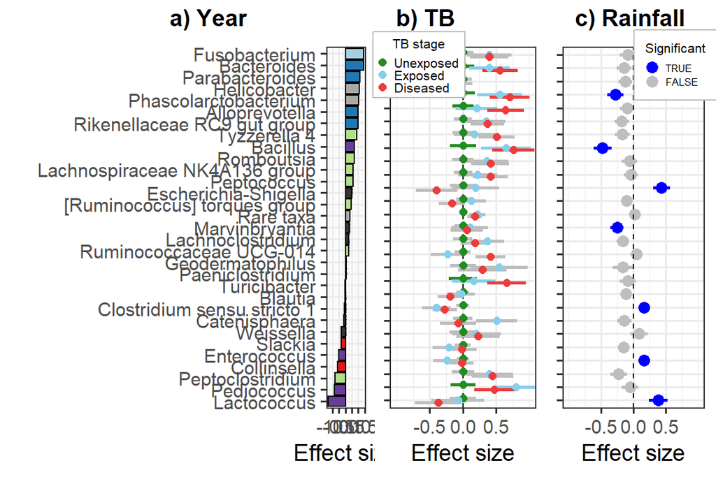

```r
# Combining plots
rm_legend <- function(p){p + theme(legend.position = "none")}

ggarrange(rm_legend(plot_tb_1), plot_tb_2, plot_rainfall, nrow = 1, align = "h", widths = c(2.2,1,1), labels = c("a) Year", "b) TB", "c) Rainfall"), label.x = c(0.35,-0.05,-0.15))
```

```r
#
```

This chunk took 0.13 minutes